# Tp53 SNV hotspots

K S Gaonkar (D3B)

In this notebook we will add TP53 alteration status as discussed in [#837](https://github.com/AlexsLemonade/OpenPBTA-analysis/issues/837):

**TP53 altered - loss**, if :

- A sample contains a TP53 hotspot SNV mutation. (Cancer hotspot database and downloadable file available). Please also crosscheck that all mutations from this table are included.
- A sample contains two TP53 alterations, suggesting (but not confirming) that both alleles are affected (SNV+SNV, (CNV or SV) + SNV).
- A sample contains one alteration (SNV or (CNV or SV)) + has cancer_predispositions == “Li-Fraumeni syndrome”, suggesting there is a germline variant in addition to the somatic variant we observe.
- A sample does not have a TP53 alterations, but has cancer_predispositions == “Li-Fraumeni syndrome” and TP53 classifier score for matched RNA-Seq > 0.5 (or higher cutoff we decide upon later).

Note: CNV and SV will be considered as the same event, but we will be adding SV_counts and SV.type to the altered status output file

**TP53 altered - activated**, if:

- A sample contains one of the two TP53 activating mutations p.R273C and p.R248W. [@doi:10.1038/ng0593-42]

## Setup

```r
library("ggpubr")
library("ggthemes")
library("tidyverse")
library("ggfortify")
library("broom")

# rootdir
root_dir <- rprojroot::find_root(rprojroot::has_dir(".git"))
scratch_dir <- file.path(root_dir, "scratch")
data_dir <- file.path(root_dir, "data")

input_dir <- file.path(root_dir,
                       "analyses",
                       "tp53_nf1_score",
                       "input")

# histology
clinical<-read.delim(file.path(data_dir,"Hope-GBM-histologies-base.tsv"))

histology <- clinical %>%
  dplyr::select("Kids_First_Biospecimen_ID",
        "sample_id",
        "Kids_First_Participant_ID",
        "cancer_predispositions",
        "sample_type",
        "experimental_strategy",
        "composition",
        "cohort")
gbm_muts <- read_tsv(file.path(input_dir, "harmonized_mutation_06082023.tsv"))
# Cancer database
hotspot_database_2017_tp53_snv <- readxl::read_xls(file.path(input_dir,"hotspots_v2.xls"),sheet = 1) %>%
  filter(Hugo_Symbol == "TP53")
hotspot_database_2017_tp53_indel <- readxl::read_xls(file.path(input_dir,"hotspots_v2.xls"),sheet = 2) %>%
  filter(Hugo_Symbol == "TP53")

# p53, p63 and p73 functional sites
functional_sites_tp53 <- read_tsv(file.path(input_dir,"hotspot_Chen_2006.tsv"))
results_dir <- file.path(root_dir,
                         "analyses",
                         "tp53_nf1_score",
                         "results")

if (!dir.exists(results_dir)) {
  dir.create(results_dir)
}

# Read in combined scores from tp53-nf1-classifier
classifier_score <- read_tsv(file.path(results_dir, "combined_scores.tsv")) %>%
  select(!sample_id) %>%
  dplyr::rename(Kids_First_Biospecimen_ID_RNA = Kids_First_Biospecimen_ID) %>%
  filter(Kids_First_Biospecimen_ID_RNA %in% histology$Kids_First_Biospecimen_ID) %>%
  left_join(histology, by=c("Kids_First_Biospecimen_ID_RNA"="Kids_First_Biospecimen_ID"))
# Copy number per sample
# overlapping functional domain
cnv_domain_overlap <- read_tsv(
  file.path(
    results_dir,
    "loss_overlap_domains_tp53.tsv"))
# Structural variant overlapping
# or within gene locus of TP53
sv_overlap <- read_tsv(
  file.path(
    results_dir,
    "sv_overlap_tp53.tsv"))
## generate a empty file for sv_overlap ##
sv_overlap <- data.frame(SV_chrom = NA, SV_start = NA, SV_end = NA,
                         SV_length = NA, Kids.First.Biospecimen.ID.Tumor = NA, SV_type = NA,
                         Gene_name = NA, ALT = NA, sample_id = NA)

# Structural variant as a fusion in exon1/intron1
fusion_overlap <- read_tsv(
  file.path(
    results_dir,
    "fusion_bk_tp53_loss.tsv"))
```

### Check if all function sites are in hotspots

All functional sites are just 1 base so checking in `hotspot_database_2017_snv`

```r
functional_sites_tp53 %>%
  filter(!gsub("[A-Z|a-z]","",p53) %in% hotspot_database_2017_tp53_snv$Amino_Acid_Position )
```

| p53 | p63 | p73 |
| --- | --- | --- |
| A276 | A307 | A296 |
| R283 | K314 | K303 |

2 functional sites are missing in hotspots database.

## SNV for TP53

Removing Silent or Intron classified variants to capture only putative damaging mutations

```r
consensus_tp53_snv_indel <- data.table::fread(
  file.path(data_dir,"Hope-snv-consensus-plus-hotspots.maf.tsv.gz"), select =
  c("Chromosome",
         "Start_Position",
         "End_Position",
         "Strand",
         "Variant_Classification",
         "Tumor_Sample_Barcode",
         "SYMBOL",
         "HGVSp_Short"),
  tmpdir = scratch_dir) %>%
  rename("Kids_First_Biospecimen_ID" = "Tumor_Sample_Barcode") %>%
  rename(Hugo_Symbol = SYMBOL) %>%
  filter(Hugo_Symbol == "TP53") %>%
  filter(!(Variant_Classification %in% c("Silent", "Intron",
                                         # remove other non-amino acid SNVs
                                         "3'Flank" ,"5'Flank",
                                         "3'UTR", "5'UTR"  )))
```

### Gather annotation for SNV

hotspots : overlaps AA position which are statistically significant SNV/Indels activating : overlaps AA position which are found to act as gain-of-function according to literature

```r
consensus_tp53_snv_indel <- consensus_tp53_snv_indel %>%
  mutate(
    hotspot = case_when(
      # strip REF and Variant AA to get Amino_Acid_Position in consensus maf
      (gsub("[A-Z|a-z]|[.]","",HGVSp_Short) %in%
         # if overlaps the hotspot Amino_Acid_Position
         hotspot_database_2017_tp53_snv$Amino_Acid_Position)  ~ 1,
      TRUE ~ 0),
    activating = case_when(
      # strip REF and Variant AA to get Amino_Acid_Position in consensus maf
      (gsub("[A-Z|a-z]|[.]","",HGVSp_Short) %in%
         # if overlaps the activating  Amino_Acid_Position
         c("273","248"))  ~ 1,
      TRUE ~ 0
    )
  )
```

## Gather SNV,CNV, classifier and cancer_predisposition values

We will gather values per sample_id since DNA and RNA samples can be only matched by `sample_id`

```r
tp53_alterations <- histology %>%
  filter(experimental_strategy %in% c("WGS", "WES")) %>%
  # filter for Tumors
  filter(sample_type=="Tumor") %>%
  # join consensus calls overlapping hotspots
  left_join(consensus_tp53_snv_indel,
            by=c("Kids_First_Biospecimen_ID"="Kids_First_Biospecimen_ID")) %>%
  # join filtered cnv losses
  left_join(cnv_domain_overlap,by=c("Kids_First_Biospecimen_ID"="biospecimen_id",
                                    "sample_id", "Kids_First_Participant_ID",
                                    "composition")) %>%
  # join SV
  left_join(sv_overlap,by=c("Kids_First_Biospecimen_ID"="Kids.First.Biospecimen.ID.Tumor",
                            "sample_id")) %>%
  dplyr::rename(Kids_First_Biospecimen_ID_DNA = Kids_First_Biospecimen_ID) %>%
  # join fusion
  left_join(fusion_overlap,by="sample_id")

tp53_alterations_score <- tp53_alterations %>%
  # add classifier score
  full_join(classifier_score,by=c("sample_id",
                                  "composition",
                                  #"cell_line_composition",
                                  "cancer_predispositions",
                                  "sample_type",
                                  "Kids_First_Participant_ID",
                                  "cohort")) %>%
  # select useful columns
  dplyr::select(sample_id, Kids_First_Biospecimen_ID_RNA, Kids_First_Biospecimen_ID_DNA,
         tp53_score, cancer_predispositions, HGVSp_Short, copy_number, SV_type, FusionName, hotspot, activating) %>%
  arrange(sample_id) %>%
  unique() %>%
  replace_na(list(hotspot = 0, activating = 0))

tp53_alterations_score
```

|  | sample_id | Kids_First_Biospecimen_ID_RNA | Kids_First_Biospecimen_ID_DNA | tp53_score | cancer_predispositions | HGVSp_Short | copy_number | SV_type | FusionName | hotspot | activating |
| --- | --- | --- | --- | --- | --- | --- | --- | --- | --- | --- | --- |
| 1 | 7316-1052 | BS_TGS109T3 | BS_3HXCGJ4J | 0.704708170 | None documented | NA | NA | NA | NA | 0 | 0 |
| 2 | 7316-1099 | BS_052PZFMK | BS_EPM623G4 | 0.902157660 | None documented | p.Q192* | NA | NA | NA | 0 | 0 |
| 3 | 7316-1106 | BS_H1XPVS9A | BS_J4E9SW51 | 0.069304860 | None documented | NA | NA | NA | NA | 0 | 0 |
| 4 | 7316-114 | BS_23QW0BBA | BS_3NX3RBCX | 0.134625758 | None documented | NA | 1 | NA | NA | 0 | 0 |
| 5 | 7316-1455 | BS_HE0WJRW6 | BS_16JT2DCA | 0.976213584 | Li-Fraumeni syndrome (TP53) | NA | NA | NA | NA | 0 | 0 |
| 6 | 7316-161 | BS_SHJA4MR0 | BS_W2QCHQ7E | 0.785647815 | None documented | p.R342P | NA | NA | NA | 1 | 0 |
| 7 | 7316-161 | BS_SHJA4MR0 | BS_W2QCHQ7E | 0.785647815 | None documented | p.P72Lfs*48 | NA | NA | NA | 0 | 0 |
| 8 | 7316-1723 | BS_8ZS9F31R | BS_D7PRJEMD | 0.018494296 | None documented | NA | NA | NA | NA | 0 | 0 |
| 9 | 7316-1746 | BS_R5SNFB5B | BS_ASGBEHAX | 0.474960754 | None documented | p.Y163C | NA | NA | NA | 1 | 0 |
| 10 | 7316-1763 | BS_6WP1FHTE | BS_WPCBK1EG | 0.698445869 | None documented | p.R213* | NA | NA | NA | 0 | 0 |

[output cut: 185 more lines]

Convert the above to wide format

```r
tp53_alterations_score_wide <- tp53_alterations_score %>%
  # group
  group_by(sample_id,
           Kids_First_Biospecimen_ID_DNA,
           Kids_First_Biospecimen_ID_RNA,
           cancer_predispositions,
           tp53_score) %>%
  #
  # sample_id as rows add SNV counts,CNV loss counts
  # and hotspot/activating mutation annotation
  summarise(
    # summarize length of SNV and CNV alterations
   SNV_indel_counts= length(unique(HGVSp_Short[!is.na(HGVSp_Short)])),
    CNV_loss_counts = length(unique(copy_number[!is.na(copy_number)])),
    SV_counts = length(unique(SV_type[!is.na(SV_type)])),
    Fusion_counts = length(unique(FusionName[!is.na(FusionName)])),
    HGVSp_Short = toString(unique(HGVSp_Short)),
    CNV_loss_evidence = toString(unique(copy_number)),
    SV_type = toString(unique(SV_type)),
    Fusion_evidence = toString(unique(FusionName)),
    # summarize unique hotspot values per sample_id
    hotspot = max(unique(hotspot[!is.na(hotspot) ])),
    activating = max(unique(activating[!is.na(activating)])))
```

[output not shown]

```r
tp53_alterations_score_wide
```

| sample_id | Kids_First_Biospecimen_ID_DNA | Kids_First_Biospecimen_ID_RNA | cancer_predispositions | tp53_score | SNV_indel_counts | CNV_loss_counts | SV_counts | Fusion_counts | HGVSp_Short | CNV_loss_evidence | SV_type | Fusion_evidence | hotspot | activating |
| --- | --- | --- | --- | --- | --- | --- | --- | --- | --- | --- | --- | --- | --- | --- |
| 7316-1052 | BS_3HXCGJ4J | BS_TGS109T3 | None documented | 0.704708170 | 0 | 0 | 0 | 0 | NA | NA | NA | NA | 0 | 0 |
| 7316-1099 | BS_EPM623G4 | BS_052PZFMK | None documented | 0.902157660 | 1 | 0 | 0 | 0 | p.Q192* | NA | NA | NA | 0 | 0 |
| 7316-1106 | BS_J4E9SW51 | BS_H1XPVS9A | None documented | 0.069304860 | 0 | 0 | 0 | 0 | NA | NA | NA | NA | 0 | 0 |
| 7316-114 | BS_3NX3RBCX | BS_23QW0BBA | None documented | 0.134625758 | 0 | 1 | 0 | 0 | NA | 1 | NA | NA | 0 | 0 |
| 7316-1455 | BS_16JT2DCA | BS_HE0WJRW6 | Li-Fraumeni syndrome (TP53) | 0.976213584 | 0 | 0 | 0 | 0 | NA | NA | NA | NA | 0 | 0 |
| 7316-161 | BS_W2QCHQ7E | BS_SHJA4MR0 | None documented | 0.785647815 | 2 | 0 | 0 | 0 | p.R342P, p.P72Lfs*48 | NA | NA | NA | 1 | 0 |
| 7316-1723 | BS_D7PRJEMD | BS_8ZS9F31R | None documented | 0.018494296 | 0 | 0 | 0 | 0 | NA | NA | NA | NA | 0 | 0 |
| 7316-1746 | BS_ASGBEHAX | BS_R5SNFB5B | None documented | 0.474960754 | 1 | 0 | 0 | 0 | p.Y163C | NA | NA | NA | 1 | 0 |
| 7316-1763 | BS_WPCBK1EG | BS_6WP1FHTE | None documented | 0.698445869 | 1 | 0 | 0 | 0 | p.R213* | NA | NA | NA | 0 | 0 |
| 7316-1769 | BS_KY1CTGJ3 | BS_1A6MQ9ZA | None documented | 0.430517771 | 0 | 0 | 0 | 0 | NA | NA | NA | NA | 0 | 0 |

[output cut: 179 more lines]

### Add GBM samples

```r
gbm_tp53 <- gbm_muts %>%
  filter(ApprovedGeneSymbol == "TP53") %>%
  pivot_longer(cols = -ApprovedGeneSymbol, names_to = "sample_id", values_to = "GBM_TP53_SNV") %>%
  select(-ApprovedGeneSymbol) %>%
  filter(grepl("^C3", sample_id))

tp53_alterations_score_wide <- tp53_alterations_score_wide %>%
  left_join(gbm_tp53, by = "sample_id") %>%
  mutate(SNV_indel_counts = case_when(GBM_TP53_SNV == 1 ~ 1,
                                      GBM_TP53_SNV == 0 ~ 0,
                                      TRUE ~ SNV_indel_counts)) %>%
  select(-GBM_TP53_SNV)
```

### Add annotation

As discussed above we want to annotate TP53 mutants that are putative loss-of-function OR gain-of-function.

```r
tp53_alterations_score_wide <- tp53_alterations_score_wide %>%
  mutate(
    # add tp53_altered annotation column
    tp53_altered =
      case_when(
        # when activating == 0
        activating == 0 &
          # check if mutated variant AA position overlaps hotspot database
          ( hotspot == 1  |
              # check if sample_id has SNV+(CNV|SV) mutation
              # suggesting both alleles are mutated
              (SNV_indel_counts >= 1 &
                 (CNV_loss_counts >=1 | SV_counts >=1) ) |
              # check if more than 1 SNV is present
              # suggesting both alleles are mutated
              SNV_indel_counts > 1 |
              # check if SNV mutant and has
              # Li-Fraumeni syndrome suggesting
              # germline TP53 mutant as cancer predisposition
              (SNV_indel_counts >= 1 &
                             grepl("Li-Fraumeni syndrome",cancer_predispositions)) |
              # check if CNV|SV mutant  and has
              # Li-Fraumeni syndrome suggesting
              # germline TP53 mutant as cancer predisposition
              ((CNV_loss_counts >= 1 | SV_counts >=1 ) &
                             grepl("Li-Fraumeni syndrome",cancer_predispositions)) |
              # check if tp53 inactivating score for RNA_Seq is greater that 0.5
              # and has Li-Fraumeni syndrome suggesting
              # germline TP53 mutant as cancer predisposition
              (tp53_score > 0.5 &
                             grepl("Li-Fraumeni syndrome",cancer_predispositions)) |
              # check if tp53 inactivating score for RNA_Seq is greater that 0.5
              # and has 1 or more SNV| (CNV|SV) loss in TP53
              (tp53_score > 0.5 &
                             (SNV_indel_counts >= 1 | (CNV_loss_counts >=1 | SV_counts >=1 )))
          ) ~ "loss",
        # when activating == 1
        activating == 1 ~ "activated",
        # if no evidence supports TP53 inativation or activation
        TRUE ~ "other"
      )
  )
```

## Explore distribution of tp53_altered status vs tp53 inactivation scores

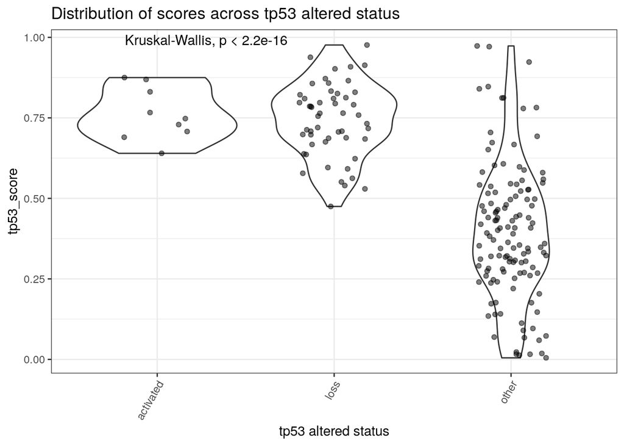

```r
ggplot(tp53_alterations_score_wide, aes(x = factor(tp53_altered), y = tp53_score)) +
  geom_violin()+
  geom_jitter(alpha = 0.5, width = 0.2) +
  stat_compare_means() +
  theme_bw() +
  ggtitle("Distribution of scores across tp53 altered status") +
  theme(axis.text.x = element_text(angle = 60, hjust = 1))+
  xlab("tp53 altered status")
```

TP53 mutants with gain-of-function (activating) mutants promote tumorigenesis according to literature. [Reference](https://pubmed.ncbi.nlm.nih.gov/17417627/) and [reference](https://pubmed.ncbi.nlm.nih.gov/24677579/) have similar distribution of classifier scores to that of potential loss-of-function (multi-allelic) Tp53 mutations.

“Other” annotated samples either don’t have any high-confidence loss/gain TP53 SNVs nor CNV losses OR DNA sample is not available.

### Expression profile for activating vs loss TP53 status

```r
expr_combined <- readRDS(file.path(data_dir,"Hope-and-CPTAC-GBM-gene-expression-rsem-tpm-collapsed.rds"))
```

#### Expression profile for activating vs loss TP53 status

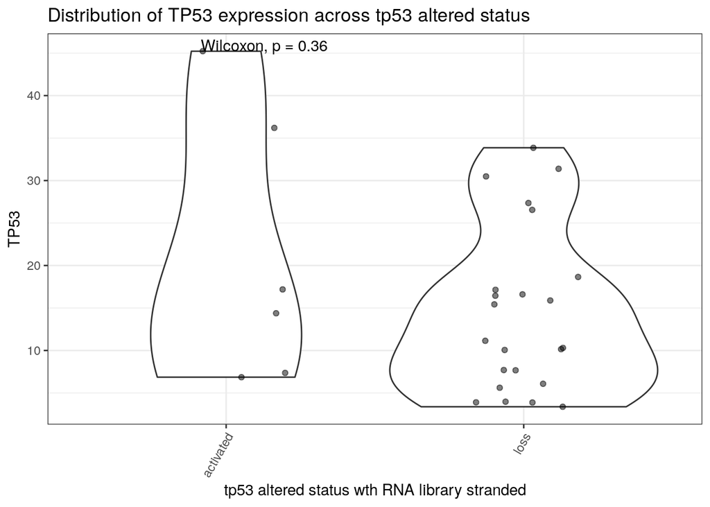

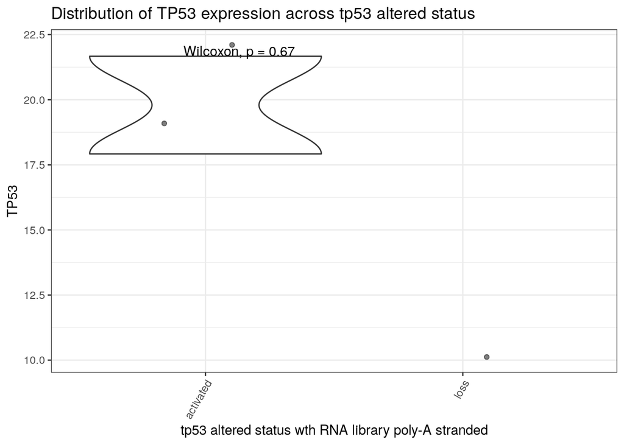

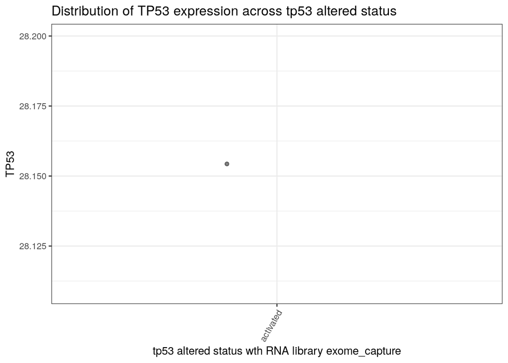

[figure not shown]

```r
# iterate through all possible RNA library type
# first filter to
clinical_filtered <- clinical %>%
  filter(Kids_First_Biospecimen_ID %in% names(expr_combined))

# generate list of all RNA library type
rna_library_list <- clinical_filtered %>%
  filter(Kids_First_Biospecimen_ID %in% names(expr_combined)) %>%
  pull(RNA_library) %>%
  unique()

for(i in 1:length(rna_library_list)) {

  library_each <- rna_library_list[[i]]
  # pull BS IDs for that RNA library type
  library_samples <- clinical_filtered %>%
    filter(RNA_library == library_each) %>%
    pull(Kids_First_Biospecimen_ID) %>%
    unique()
  # subset expression matrix using that
  expr_each <- expr_combined %>%
    dplyr::select(library_samples)

  # subset to TP53
  subset_expr_each <- t(expr_each)[,"TP53"] %>%
    as.data.frame()
  colnames(subset_expr_each) <- "TP53"

  # combine the TP53 alteration information
  subset_expr_combined <- subset_expr_each %>%
    tibble::rownames_to_column() %>%
    left_join(tp53_alterations_score_wide,by=c("rowname"="Kids_First_Biospecimen_ID_RNA")) %>%
    filter(tp53_altered %in% c("activated","loss"))

  # plot distribution of TP53 gene expression
  plot<- ggplot(subset_expr_combined, aes(x = factor(tp53_altered), y = TP53)) +
    geom_violin()+
    geom_jitter(alpha = 0.5, width = 0.2) +
    stat_compare_means() +
    theme_bw() +
    ggtitle("Distribution of TP53 expression across tp53 altered status") +
    theme(axis.text.x = element_text(angle = 60, hjust = 1))+
    xlab(paste0("tp53 altered status wth RNA library ", library_each))

  print(plot)
}
```

### Check if other cancer predisposition have high TP53 inactivation scores

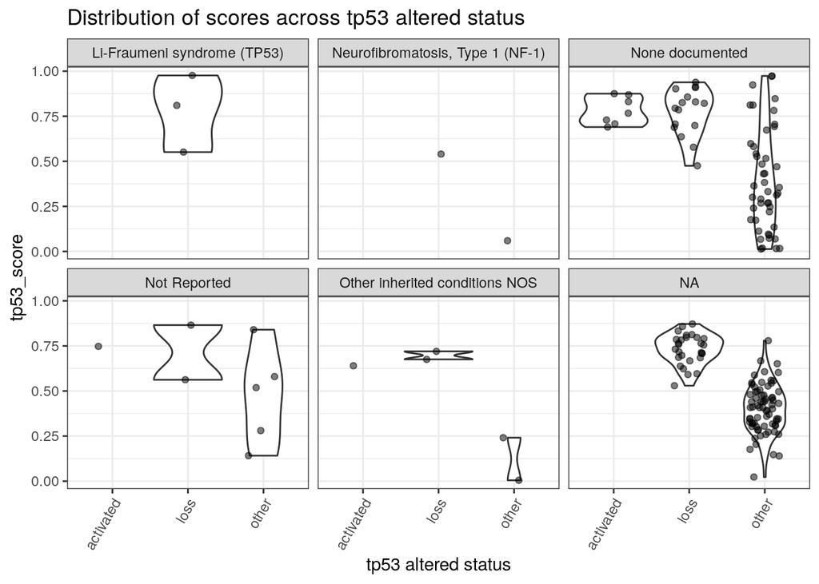

```r
ggplot(tp53_alterations_score_wide, aes(x = factor(tp53_altered), y = tp53_score)) +
  geom_violin()+
  geom_jitter(alpha = 0.5, width = 0.2) +
  theme_bw() +
  ggtitle("Distribution of scores across tp53 altered status") +
  theme(axis.text.x = element_text(angle = 60, hjust = 1))+
  xlab("tp53 altered status") +
  facet_wrap(.~cancer_predispositions)
```

Some NF-1 and/or Other inherited conditions NOS have high scoring TP53 mutants as well.

```r
tp53_alterations_score_wide %>%
  filter(grepl("Li-Fraumeni syndrome", cancer_predispositions),
         tp53_score < 0.5)
```

| sample_id | Kids_First_Biospecimen_ID_DNA | Kids_First_Biospecimen_ID_RNA | cancer_predispositions | tp53_score | SNV_indel_counts | CNV_loss_counts | SV_counts | Fusion_counts | HGVSp_Short | CNV_loss_evidence | SV_type | Fusion_evidence | hotspot | activating | tp53_altered |
| --- | --- | --- | --- | --- | --- | --- | --- | --- | --- | --- | --- | --- | --- | --- | --- |

## Save file

Adding DNA and RNA biospecimen ids to `tp53_alterations_score_wide` and saving

```r
tp53_alterations_score_wide %>%
  write_tsv(file.path(results_dir,"tp53_altered_status.tsv"))
```